# R Notebook

```r
library(tidyverse)
library(janitor)
```

```r
mtcars %>%
  select(wt, mpg) %>%
  glimpse()
```

```
Rows: 32
Columns: 2
$ wt  <dbl> 2.620, 2.875, 2.320, 3.215, 3.440, 3.460…
$ mpg <dbl> 21.0, 21.0, 22.8, 21.4, 18.7, 18.1, 14.3…
```

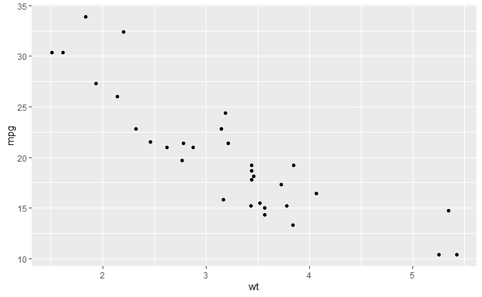

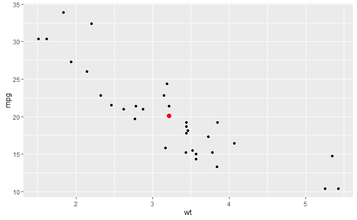

# Pearson correlation coefficient

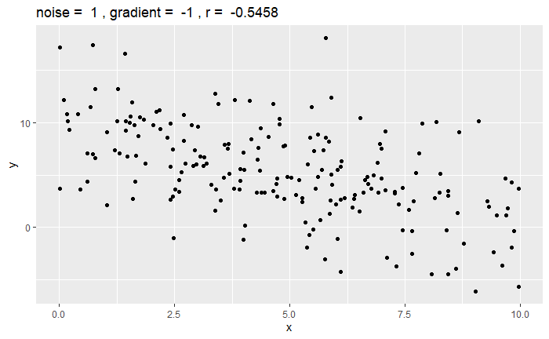

| cor(mpg, wt) |
| --- |
| -0.8676594 |

| cor(wt, mpg) |
| --- |
| -0.8676594 |

```r
# Pivot longer:
anscombe_long <- anscombe %>%
pivot_longer(everything(),
names_to = c(".value", "set"),
names_pattern = c("(\\D+)(\\d+)"))

# Group by set and get the correlation coefficient for each:
anscombe_long %>%
group_by(set) %>%
summarise(r = cor(x, y))
```

| set | r |
| --- | --- |
| 1 | 0.8164205 |
| 2 | 0.8162365 |
| 3 | 0.8162867 |
| 4 | 0.8165214 |

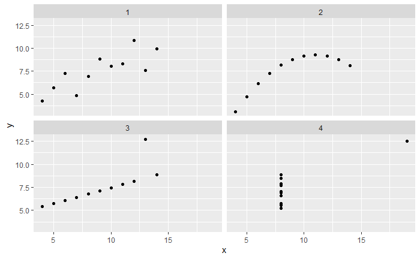

```r
# Plot the quartet:
anscombe_long %>%
ggplot() +
aes(x = x, y = y) +
geom_point() +
facet_wrap(~set)
```

# Task - 10 minutes

Now calculate the four correlation coefficients between the data pairs plotted above (x1 with y1 and so on). The data can be found in the built-in anscombe dataset. What do you notice about the correlation coefficients? Looking at each plot, think about whether the resulting coefficient accurately represents the pattern in the data.

```r
anscombe_long %>%
  group_by(set) %>%
  summarise(r = cor(x, y))
```

| set | r |
| --- | --- |
| 1 | 0.8164205 |
| 2 | 0.8162365 |
| 3 | 0.8162867 |
| 4 | 0.8165214 |

```r
NA
```

The correlation coefficients are very similar between each data set. However, the plot themselves are very different therefore the r-value is not useful in all scenarios, i.e. not useful for set 2 or 4.

# Task - 15 mins

Let’s calculate correlation coefficients for various variables in the state.x77 dataset!

| population | income | illiteracy | life_exp | murder | hs_grad | frost | area |
| --- | --- | --- | --- | --- | --- | --- | --- |
| 3615 | 3624 | 2.1 | 69.05 | 15.1 | 41.3 | 20 | 50708 |
| 365 | 6315 | 1.5 | 69.31 | 11.3 | 66.7 | 152 | 566432 |
| 2212 | 4530 | 1.8 | 70.55 | 7.8 | 58.1 | 15 | 113417 |
| 2110 | 3378 | 1.9 | 70.66 | 10.1 | 39.9 | 65 | 51945 |
| 21198 | 5114 | 1.1 | 71.71 | 10.3 | 62.6 | 20 | 156361 |
| 2541 | 4884 | 0.7 | 72.06 | 6.8 | 63.9 | 166 | 103766 |
| 3100 | 5348 | 1.1 | 72.48 | 3.1 | 56.0 | 139 | 4862 |
| 579 | 4809 | 0.9 | 70.06 | 6.2 | 54.6 | 103 | 1982 |
| 8277 | 4815 | 1.3 | 70.66 | 10.7 | 52.6 | 11 | 54090 |
| 4931 | 4091 | 2.0 | 68.54 | 13.9 | 40.6 | 60 | 58073 |

[output cut: 40 more lines]

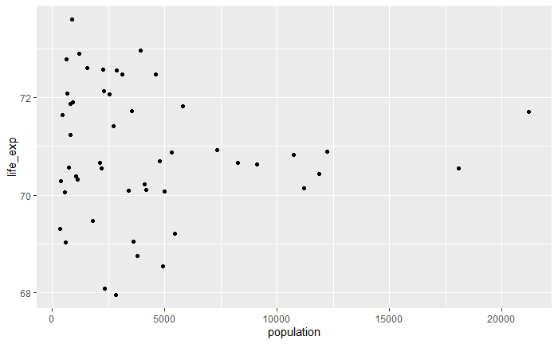

```r
# population vs life_exp
tibble_states %>%
  ggplot(aes(x = population, y = life_exp)) +
  geom_point()
```

```r
tibble_states %>%
  summarise(r = cor(population, life_exp))
```

| r |
| --- |
| -0.06805195 |

```r
NA
```

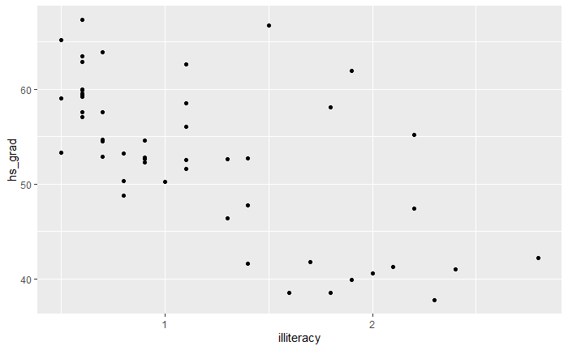

```r
# illiteracy vs hs grad

tibble_states %>%
  ggplot(aes(x = illiteracy, y = hs_grad)) +
  geom_point()
```

```r
tibble_states %>%
  summarise(r = cor(illiteracy, hs_grad))
```

| r |
| --- |
| -0.6571886 |

```r
NA
NA
```

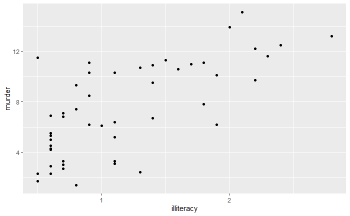

```r
# murder and illiteracy

tibble_states %>%
  ggplot(aes(x = illiteracy, y = murder)) +
  geom_point()
```

```r
tibble_states %>%
  summarise(r = cor(illiteracy, murder))
```

| r |
| --- |
| 0.7029752 |

```r
NA
```

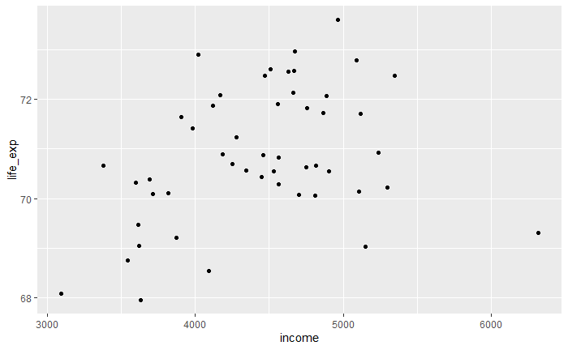

```r
# income and life expectancy

tibble_states %>%
  ggplot(aes(x = income, y = life_exp)) +
  geom_point()
```

```r
tibble_states %>%
  summarise(r = cor(income, life_exp))
```

| r |
| --- |
| 0.3402553 |

```r
NA
```

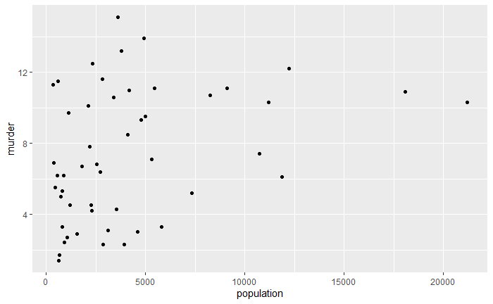

```r
# population vs murder

tibble_states %>%
  ggplot(aes(x = population, y = murder)) +
  geom_point()
```

```r
tibble_states %>%
  summarise(r = cor(population, murder))
```

| r |
| --- |
| 0.3436428 |

```r
NA
```

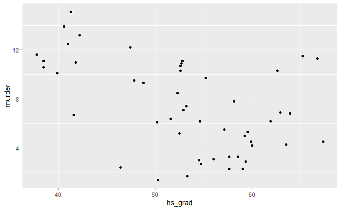

```r
# hs_grad vs murder

tibble_states %>%
  ggplot(aes(x = hs_grad, y = murder)) +
  geom_point()
```

```r
tibble_states %>%
  summarise(r = cor(hs_grad, murder))
```

| r |
| --- |
| -0.487971 |

```r
NA
NA
```

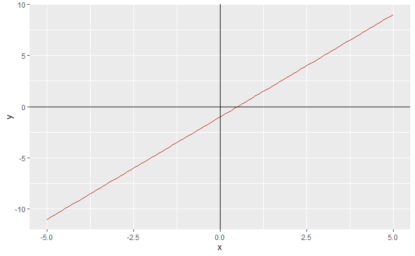

```r
line <- function(x, a, b) {
  return(a*x + b)
}

data <- tibble(
  x = seq(-5, 5, 0.1),
  y = line(x, a = 2, b = -1)
)

data %>%
  ggplot(aes(x, y)) +
  geom_line(col = "firebrick") +
  geom_vline(xintercept = 0) +
  geom_hline(yintercept = 0)
```

# Task - 5 mins

Play around plotting two or three different lines. Try a line with a=0 a=0 and positive b. You can use mutate() to overwrite y in data from above Can we use our line() function to plot a perfectly vertical line?

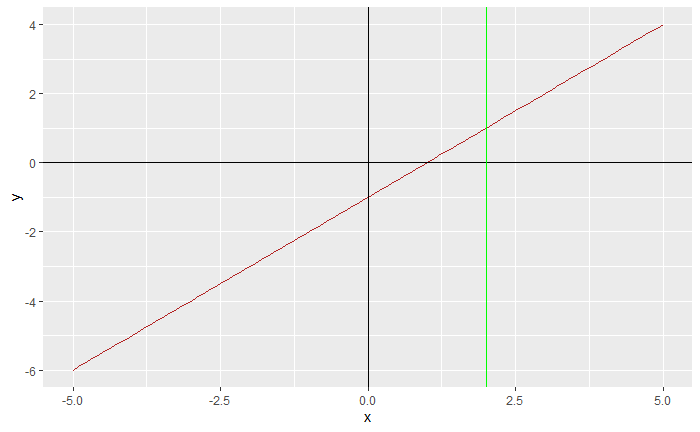

```r
data <- data %>%
  mutate(y = line(x, a = 1, b = -1))

data %>%
  ggplot(aes(x, y)) +
  geom_line(col = "firebrick") +
  geom_vline(xintercept = 0) +
  geom_hline(yintercept = 0) +
  geom_vline(xintercept = 2, col = "green")
```

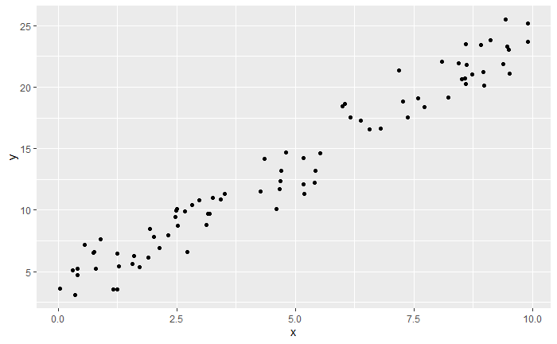

```r
noisy_line <- read_csv("data/noisy_line.csv")
noisy_line_plot <- noisy_line %>%
  ggplot(aes(x, y)) +
  geom_point()

noisy_line_plot
```

| x | y |
| --- | --- |
| 4.806482 | 13.44237 |

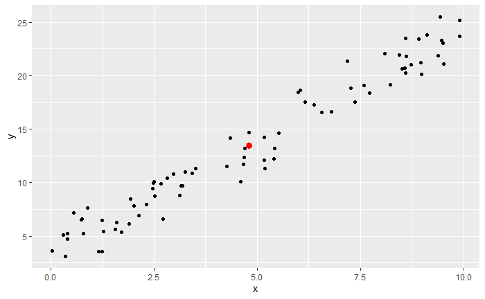

```r
get_intercept <- function(slope, centroid_x, centroid_y) {
  return(centroid_y - slope * centroid_x)
}
```

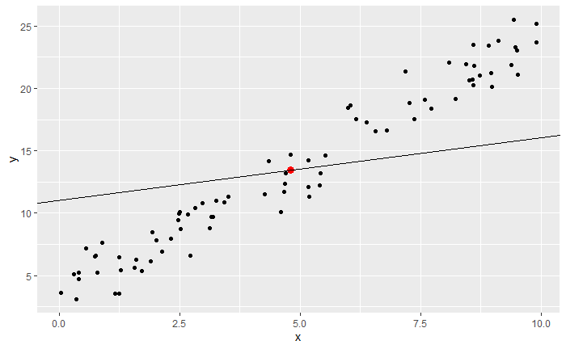

```r
slope <- 0.5

noisy_line_plot +
  geom_abline(slope = slope,
              intercept = get_intercept(slope, centroid$x, centroid$y))
```

# Task - 5 mins

Play around with the code chunk above and try to find a slope that fits the data reasonably well.

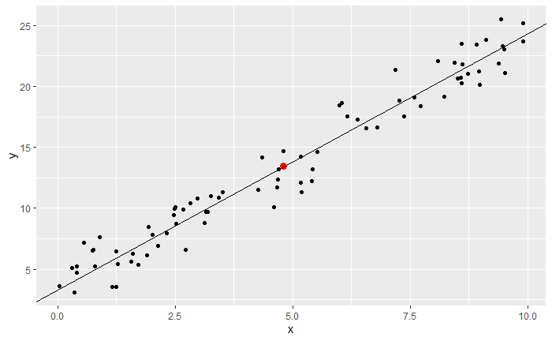

```r
slope <- 2.1

noisy_line_plot +
  geom_abline(slope = slope,
              intercept = get_intercept(slope, centroid$x, centroid$y))
```

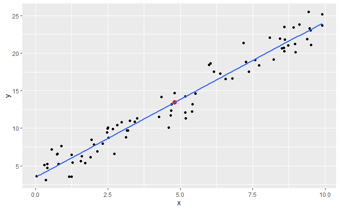